# Flow Cytometry in R with openCyto

## Intro

Welcome to openCyto. openCyto is an R framework developed in 2014. Today we are going to focus on the basics. At the centre of openCyto’s infrastructure is something called `flowCore`. This package was developed way back in 2009. Remember 2009? It was the year when this photos like this went viral:

[figure not shown]

simpler times…

You can read all about flowCore over at the [Bioconductor](https://bioconductor.org/packages/release/bioc/html/flowCore.html) website. Here are some extra resources as well:

- https://bmcbioinformatics.biomedcentral.com/articles/10.1186/1471-2105-10-106
- https://bioconductor.org/packages/release/bioc/vignettes/flowCore/inst/doc/HowTo-flowCore.pdf

I’m going to gently introduce you to flowCore’s data structures within the openCyto framework.

## Dependencies

```r
require(openCyto)
require(ggcyto)
require(MASS)
require(data.table)
```

## Reading data into R

You can think of the data being organised as so:

- At the lowest level is the `flowFrame` (see below)
- Each fcs file will be contained in its how `flowFrame` embedded in a `flowSet`
  - we actually load data as an `ncdfFlowSet` - this is an optimised data structure where the the `flowSet` is stored on disk and only parts are loaded into memory as and when needed. This is important because .fcs files are big!
- `GatingSet` objects then hold everything together and is the main API that the user will interact with. It is a container that holds `GatingHierarchy`. Think of a `GatingSet` as corresponding to a `flowSet` and a `GatingHierarchy` as corresponding to a `flowFrame`.
  - IMPORTANT `GatingSet` uses externnal pointers and therefore uses a reference semantic - i.e. functions that operative on a `GatingSet` have the potential side-effect of modifying the object

We going to start at the highest level - a `GatingSet` - and then work down to the `flowFrame`, exploring methods and data manipulation as we go.

### Creating a `GatingSet`

First we create a `ncdfFlowSet` - this is easy, we simple pass the path for the directory containing our FCS files to the method `read.ncdfFlowSet()`

Then we pass the resulting `ncdfFlowSet` too the `GatingSet` method.

```r
fcsFiles <- dir("/home/rossco/Documents/IIGeeks/flow/fcs/sepsis", full.names = TRUE)
ncfs  <- read.ncdfFlowSet(fcsFiles)
```

```
## All FCS files have the same following channels:
## FSC-A
## FSC-H
## FSC-W
## SSC-A
## SSC-H
## SSC-W
## Alexa Fluor 488-A
## Alexa Fluor 647-A
## APC-Cy7-A
## Alexa Fluor 405-A
## AmCyan-A
## BV605-A
## BV711-A
## PE-A
## PE-CF594-A
## 7-AAD-A
## PE-Cy5-5-A
## PE-Cy7-A
## Time
```

```
## write SEPSIS.fcs to empty cdf slot...
```

```
## done!
```

```r
gs <- GatingSet(ncfs)
```

```
## .done!
```

```r
gs
```

```
## A GatingSet with 1 samples
```

### Compensation and Transformation

*Compensation*

Before I dive into data structures and plots, I want to quickly go over compensation and transforming data.

Now typically you might need to compensate your data. Lucky for me this the compensation matrix was calculated on the machine and linked to the file. You compensate by simply passing the compensation matrix and gating strategy to the following method:

`compensate(gs, comp)`

Where `comp` is a matrix of spillover values.

I can access the compensation data as an attribute of the ‘description’ slot:

```r
#Access the flowframe of my ncfs object using square bracket notation
ncfs[[1]]@description$SPILL
```

```
##       Alexa Fluor 488-A Alexa Fluor 647-A  APC-Cy7-A Alexa Fluor 405-A
##  [1,]      1.0000000000       0.000000000 0.00000000      0.0000000000
##  [2,]      0.0235392171       1.000000000 0.04195965      0.0000000000
##  [3,]      0.0139492608       0.138099650 1.00000000      0.0000000000
##  [4,]      0.0000000000       0.000000000 0.00000000      1.0000000000
##  [5,]      0.0160253618       0.001228605 0.00000000      0.0798994416
##  [6,]      0.0000000000       0.001650347 0.00000000      0.0180152848
##  [7,]      0.0001273534       0.019416331 0.08004073      0.0723559100
##  [8,]      0.0091869148       0.000000000 0.00000000      0.0006543570
##  [9,]      0.0012582539       0.002056728 0.00000000      0.0000000000
## [10,]      0.0004837856       0.639047649 0.02890784      0.0004386491
## [11,]      0.0008901888       0.046594931 0.04174462      0.0001404892
## [12,]      0.0010123601       0.002705510 0.06273985      0.0000000000
##           AmCyan-A      BV605-A      BV711-A        PE-A   PE-CF594-A
##  [1,] 0.0951456642 0.0088973623 8.015641e-05 0.000000000 0.0000000000
```

[output cut: 24 more lines]

I can make this prettier with the levelplot function from lattice:

```r
require(lattice)
```

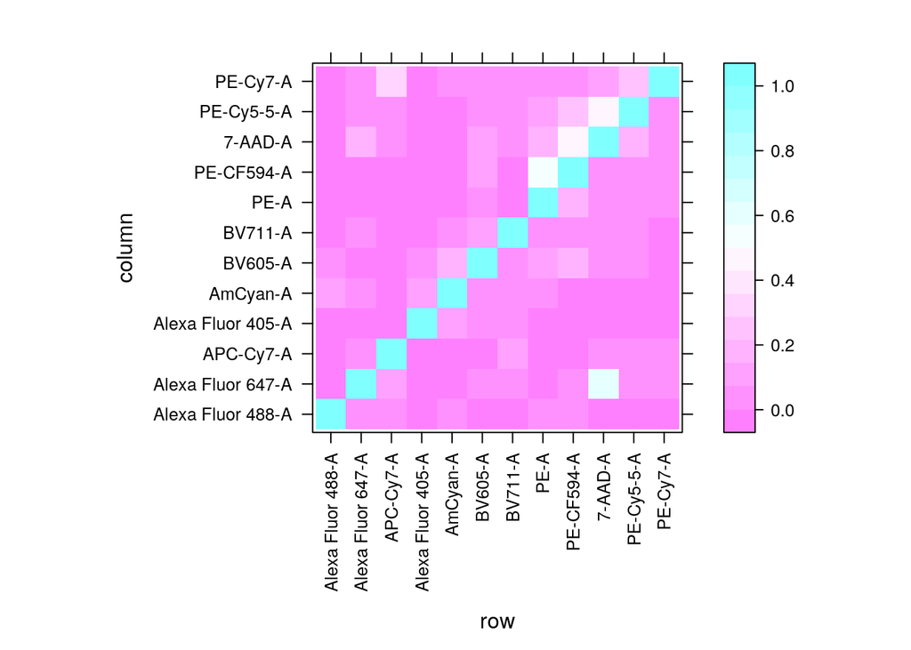

```r
m <- ncfs[[1]]@description$SPILL
rownames(m) <- paste(colnames(m))
levelplot(m, scales=list(x=list(rot=90)))
```

```r
gs <- compensate(gs, m)
```

*Transforming data*

The data is by default loaded into a `flowFrame` with a linear axis. We want to transform our data to a Logicle or Biexponential axis. This is so data is evenly distributed across the axis.

Before transformation:

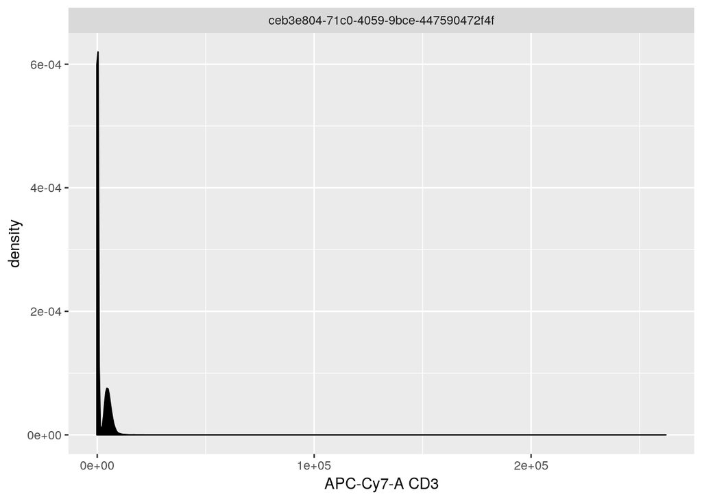

```r
autoplot(ncfs[[1]], "CD3")
```

After a logicle transform:

```r
chnls <- colnames(m)
trans <- estimateLogicle(gs[[1]], channels = chnls)
gs <- transform(gs, trans)
```

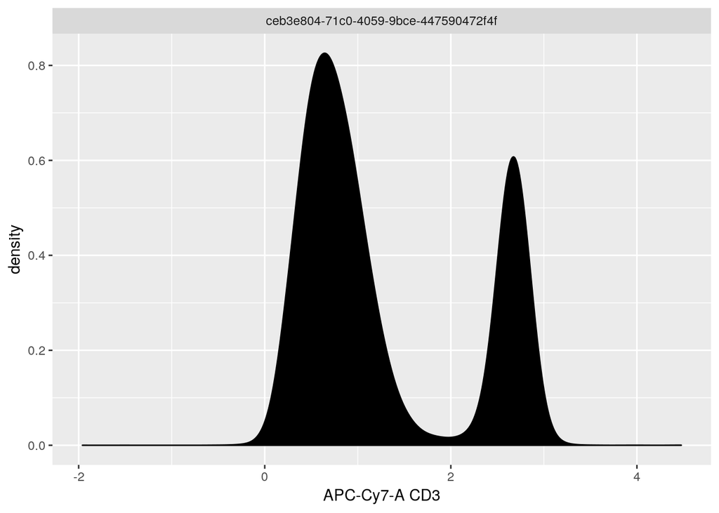

```r
autoplot(getData(gs[[1]]), "CD3")
```

Lets step through what I did in that code snippet above:

- `chnls` is just the column names from my compensation matrix. I used this because I know the columns in my compensation matrix correspond to my flourochromes and these are the columns I want to transform
- `estimateLogicle` is a method in openCyto that returns a special type of object called a `transformList`. This maps a transform function (in this case a function that transforms the data to a Logicle scale) to the list of columns in `channel`
- We then apply the transformation to the `GatingSet` using R’s transform function, this will apply the transformation to all containing `flowFrame`s

## What are all these crazy data structures?!

The main data structure you need to learn is the flowFrame, this is the basic unit and it contains three slots:

- `exprs` - contains the event level information - your intensities. This is where the data is and its stored as a simple matrix.
- `parameters` - contains column metadata stored as an annotated dataframe. All the detector and stain information is in here.
- `description`

There are a bunch of methods we can use to access elements of a flowFrame, the ones we will use most commonly are:

- `exprs()` - returns our flow data as a matrix
- `description()` - returns metadata as a list
- `parameters` - returns an annotated dataframe containing information about each column - usually constructed from keywords
- `names()` - returns a concatenated version of our column names, similar to that seen in FlowJo
- `featureNames()` - returns the discription field of the parameters
- `colnames()` - returns the detector names, often named after the fluorochrome detected
- `keyword()` - returns the raw FCS keywords. This will be a whole bunch of metadata from the machine

We can access a flowFrame by using the getData method:

```r
summary(getData(gs[[1]]))
```

```
##             FSC-A     FSC-H     FSC-W     SSC-A     SSC-H     SSC-W
## Min.     51216.00  50016.00  65443.27   1306.70   2194.00  31697.49
## 1st Qu.  77361.24  59116.00  81971.89  26027.42  23996.00  69994.83
## Median   91059.55  66618.00  89459.16  49423.92  42357.00  74027.77
## Mean    102247.69  71946.79  91907.88  65554.29  52342.69  78459.17
## 3rd Qu. 108857.10  76631.00  96387.77  76834.70  61673.00  78713.52
## Max.    262143.00 259039.00 251984.56 262143.00 256673.00 262143.00
##         Alexa Fluor 488-A Alexa Fluor 647-A  APC-Cy7-A Alexa Fluor 405-A
## Min.           -1.5851755        -2.6409976 -2.4453821         -2.115138
## 1st Qu.         0.8479492         0.8271413  0.5813764          1.014569
## Median          1.0353616         1.0876586  0.8940471          1.297954
## Mean            1.2842780         1.2476609  1.2830229          1.465195
## 3rd Qu.         1.3719205         1.5381949  2.4697380          1.736975
## Max.            4.4988422         4.5013804  4.4926710          4.496562
##          AmCyan-A   BV605-A    BV711-A       PE-A PE-CF594-A    7-AAD-A
## Min.    -0.614176 -2.301238 -1.9391910 -2.4441636 -2.1564450 -1.2261437
## 1st Qu.  1.853989  1.214381  0.7805694  0.6375571  0.7922558  0.9716797
## Median   2.336552  1.500221  0.9715369  0.9758536  1.6762064  1.0782673
## Mean     2.319827  1.523942  1.1068013  1.1088238  1.8303866  1.0307779
## 3rd Qu.  2.769272  1.819015  1.1984658  1.5103279  2.7404470  1.1543714
## Max.     4.499387  4.486816  4.4963293  4.4884567  4.4883614  4.4512053
##         PE-Cy5-5-A   PE-Cy7-A     Time
## Min.     -1.489976 -2.3307588    53.00
## 1st Qu.   1.057874  0.7283548  9611.30
## Median    1.733040  1.1797452 15722.20
## Mean      1.840267  1.4339092 15638.02
## 3rd Qu.   2.636528  1.9454540 22115.40
## Max.      4.479781  4.4874973 31447.00
```

If you just want the flourescence intensity values as a basic R matrix then you can just run the code below:

```r
f <- getData(gs[[1]])
m <- exprs(f)
head(m)
```

```
##          FSC-A FSC-H    FSC-W     SSC-A  SSC-H    SSC-W Alexa Fluor 488-A
## [1,]  80142.48 57786 90890.83 147136.61 130174 74075.81         1.0773401
## [2,] 118568.34 86550 89780.41  50255.39  45186 72888.45         0.8899865
## [3,] 104037.12 72431 94133.41  56437.76  50287 73551.91         1.2385890
## [4,] 110555.95 79482 91157.69  51353.31  46826 71872.27         0.8812106
## [5,] 104683.92 82002 83663.40  33742.79  31010 71311.43         0.8251193
## [6,] 124410.66 87109 93599.72  17115.58  16517 67911.05         1.0324161
##      Alexa Fluor 647-A APC-Cy7-A Alexa Fluor 405-A AmCyan-A   BV605-A
## [1,]         1.0038965 0.8202071         1.0039256 1.827938 0.8791917
## [2,]         1.0215046 0.2795548         1.1531241 2.897801 1.2456554
## [3,]         1.0028598 0.9864452         1.5334382 2.930353 1.2144542
## [4,]         1.0109000 1.0066183         1.2768738 2.558160 1.4704940
## [5,]         1.5585798 0.6053542         1.1615776 2.488047 1.0762043
## [6,]         0.7308825 0.3964878         0.9295598 1.822765 1.7675730
##       BV711-A       PE-A PE-CF594-A   7-AAD-A PE-Cy5-5-A  PE-Cy7-A Time
## [1,] 1.029882 0.57637489  0.8952000 1.1198862  0.9686241 0.7456608 53.0
## [2,] 1.018221 0.86251932  1.3142232 1.1486683  1.9622740 1.1660942 53.1
## [3,] 1.111683 0.09755711  2.2101636 1.0650673  2.3270462 1.7603871 53.1
## [4,] 1.044394 0.53580326  0.7923043 1.0896808  1.5000161 1.4400364 53.1
## [5,] 1.072350 1.64254487  3.4322784 0.6210231  1.7656626 1.1097448 53.2
## [6,] 1.191578 0.51129502  0.4994723 1.0859629  1.0452477 0.6319280 53.3
```

One super useful thing we can pull out of the parameters is the keywords associated to our columns i.e. what antibody is associated to what fluorochrome:

```r
parameters(f)
```

```
## An object of class 'AnnotatedDataFrame'
##   rowNames: $P1 $P2 ... $P19 (19 total)
##   varLabels: name desc ... maxRange (5 total)
##   varMetadata: labelDescription
```

```r
parameters(f)$name
```

```
##                $P1N                $P2N                $P3N
##             "FSC-A"             "FSC-H"             "FSC-W"
##                $P4N                $P5N                $P6N
##             "SSC-A"             "SSC-H"             "SSC-W"
##                $P7N                $P8N                $P9N
## "Alexa Fluor 488-A" "Alexa Fluor 647-A"         "APC-Cy7-A"
##               $P10N               $P11N               $P12N
## "Alexa Fluor 405-A"          "AmCyan-A"           "BV605-A"
##               $P13N               $P14N               $P15N
##           "BV711-A"              "PE-A"        "PE-CF594-A"
##               $P16N               $P17N               $P18N
##           "7-AAD-A"        "PE-Cy5-5-A"          "PE-Cy7-A"
##               $P19N
##              "Time"
```

```r
parameters(f)$desc
```

```
##      <NA>      <NA>      <NA>      <NA>      <NA>      <NA>      $P7S
##        NA        NA        NA        NA        NA        NA    "CD57"
##      $P8S      $P9S     $P10S     $P11S     $P12S     $P13S     $P14S
##   "CD161"     "CD3"    "CCR7"     "L/D"   "VA7-2"     "CD8" "Vdelta2"
##     $P15S     $P16S     $P17S     $P18S      <NA>
##  "CD45RA"   "PanGD"     "CD4"    "CD27"        NA
```

## Thats great!…but I want to make plots!

Plots in flow cytometry normally imply gating. When processing data in R I want you to think about processing the data in two independant ways:

- Good’ol fasion gating….but automated
- High dimensional analysis - clustering, dimesionality reduction etc

What I will cover in this notebook is gating, I’m going to leave the super fancy machine learning for another time.

[figure not shown]

Lets get plotting. Some crazy cats have built on-top of the ggplot library something called `ggcyto` which inherits all the functionality but is adapted to work with flowCore data structures.

The ggcyto library allows for three levels of interaction, at its lowest level you can use ggplot directly, this is because ggcyto’s `fortify` method empowers ggplot to interface with flowCore data structures.

I think this is mostly unnecessary thought and brings out some odd behaviours in my experience - it is reliant on you having a solid gating template setup, which we don’t have yet, we will get to that later.

For now lets look at the medium level, calls to `ggcyto`. It simplies the plotting by: * add a default scale_fill_gradientn for you * fuzzy-matching in aes by either detector or fluorochromes names (using keywords assocaited to a column - remember these are stored in the paramters slot of the flowFrame) * determine the parent popoulation automatically * exact and plot the gate object by simply referring to the child population name

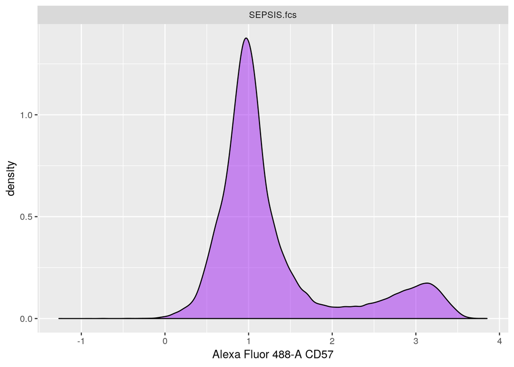

```r
fs <- getData(gs)
ggcyto(fs, aes(x = CD57)) + geom_density(fill="purple", alpha=0.5)
```

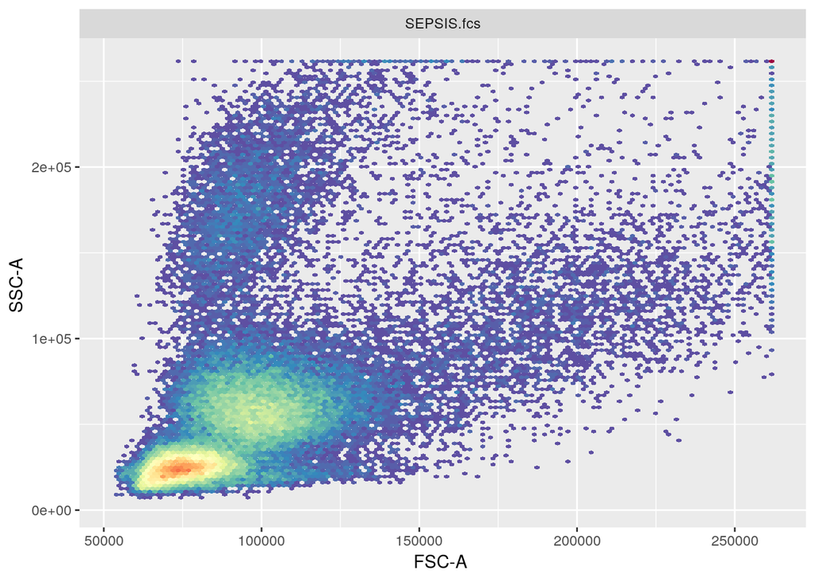

```r
ggcyto(fs, aes(x = FSC.A, y = SSC.A)) + geom_hex(bins=128)
```

At the highest level is the `autoplot` function. It inherits the spirit of R’s quick plot:

- when plotting flowSet, it determines geom type automatically by the number of dim supplied
- for GatingSet, it further skip the need of dim by guessing it from the children gate

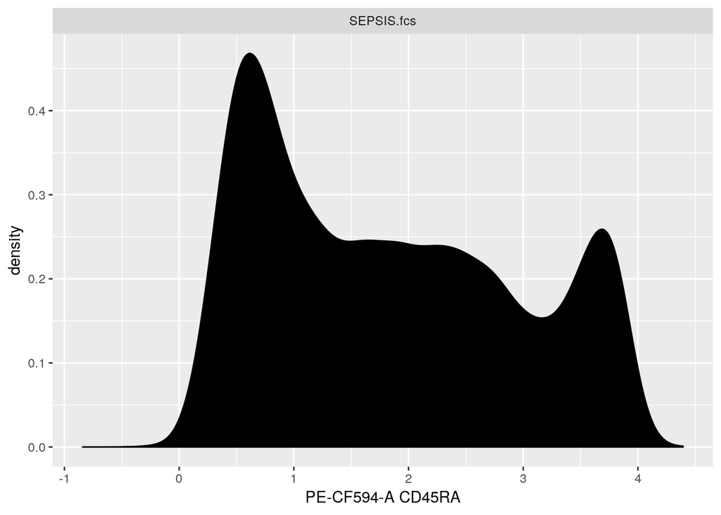

```r
autoplot(fs, "CD45RA")
```

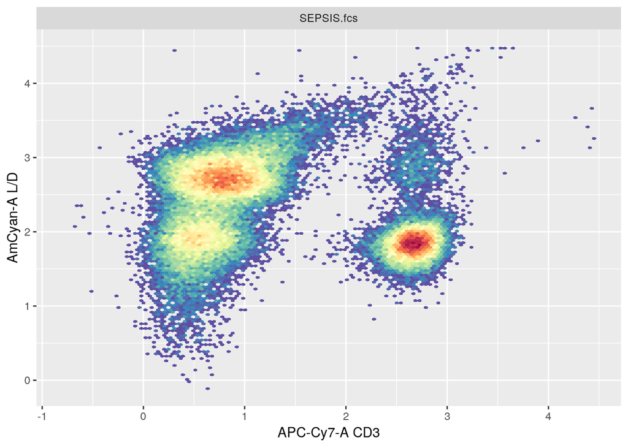

```r
autoplot(fs, "CD3", "L/D", bins=128)
```

## Gating!

So far we’ve been talking about GatingSets and GatingHierarchy but not gone into much detail as to what these are. Basically, openCyto applies a GatingTemplate to all of the samples in a GatingSet, providing a common API for accessing elements of your gated data.

We’re going to build a very simple gating strategy by adding gates directly in code the flowCore way, then I will briefly show making a gating template .csv file for the openCyto way of doing things.

To start with, here are the standard ‘manual’ gates that come with flowCore:

- **rectangleGate** Describes a cubic shape in one or more dimensions–a rectangle in one dimension is simply an interval gate.
- **polygonGate** Describes an arbitrary two dimensional polygonal gate.
- **polytopeGate** Describes a region that is the convex hull of the given points. This gate can exist in dimensions higher than 2, unlike the polygonGate.
- **ellipsoidGate** Describes an ellipsoidal region in two or more dimensions

Each of the above are more like the manual gates you get in common Flow Cytometry software like FlowJo. They are created through a function sharing their name and all take the same arguments. We’ll see some examples in a bit.

FlowCore also has two data driven gates:

- **norm2Filter** A robust method for finding a region that most resembles a bivariate Normal distribution.
- **kmeansFilter** Identifies populations based on a one dimensional k-means clustering operation. Allows the specification of multiple populations.

Gating goes on and on and on, the number of gating methods are increasing rapidly. Some of interest to me that I will be looking into are:

- flowLearn and its predesessor flowDensity (semi-supervised density matching) - considered cutting edge
- DeepCyTOF (Supervised Deep Learning method) - considered cutting edge
- flowMeans (K means based approach)
- flowStats (collection of algorithms)
- tClust
- FloCK (another K means method)
- flowPeakssvm, Kmeanssvm (k-means and density-based clustering and support vector machines)
- flowType, flowType FeaLect (1D gates extrapolated to multiple dimensions and bootstrapped LASSO classification)
- SPADE (Density-based sampling, k-means clustering)
- PRAMS (2D clustering and logistic regression)

I’m going to make a very simple gating strategy to start with, just to demonstrate the workflow. You assign the gate to an object and then can visualise using the `geom_gate` function in ggcyto.

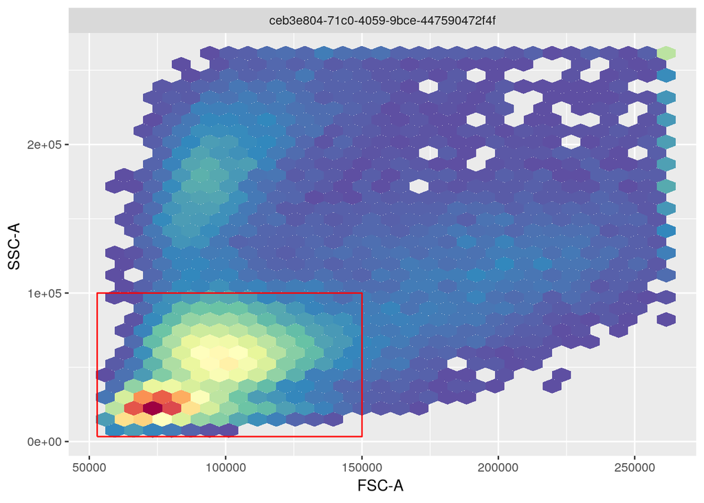

```r
#Get our flowFrame
fr <- getData(gs[[1]], "root")
chnls <- c("FSC-A", "SSC-A")
nonDebris <- rectangleGate(filterId = "nonDebris", list("FSC-A" = c(50000, 150000),"SSC-A" = c(0,100000)))
p <- autoplot(fr, x=chnls[1], y=chnls[2])
p + geom_gate(nonDebris)
```

Once we’re happy with the gate, we add it to our GatingStrategy. It’s useful to think of your GatingStrategy as a tree structure, where each gate is a node. You add the gate with the `add` function; you pass as arguments the GatingStrategy, the gate object, and the parent of the gated populations (the highest node is always “root”).

When you add a new gate you always have to run `recompute` too apply the gate to the underlying data.

```r
add(gs, nonDebris, parent = "root")
```

```
## replicating filter 'nonDebris' across samples!
```

```
## [1] 2
```

```r
recompute(gs)
```

```
## .
```

```
## done!
```

We can see the nodes in the gating structure as shown:

```r
getNodes(gs)
```

```
## [1] "root"       "/nonDebris"
```

There is also a convenience function in openCyto that overloads the base function `plot`. When passed a GatingStructure it will plot the tree:

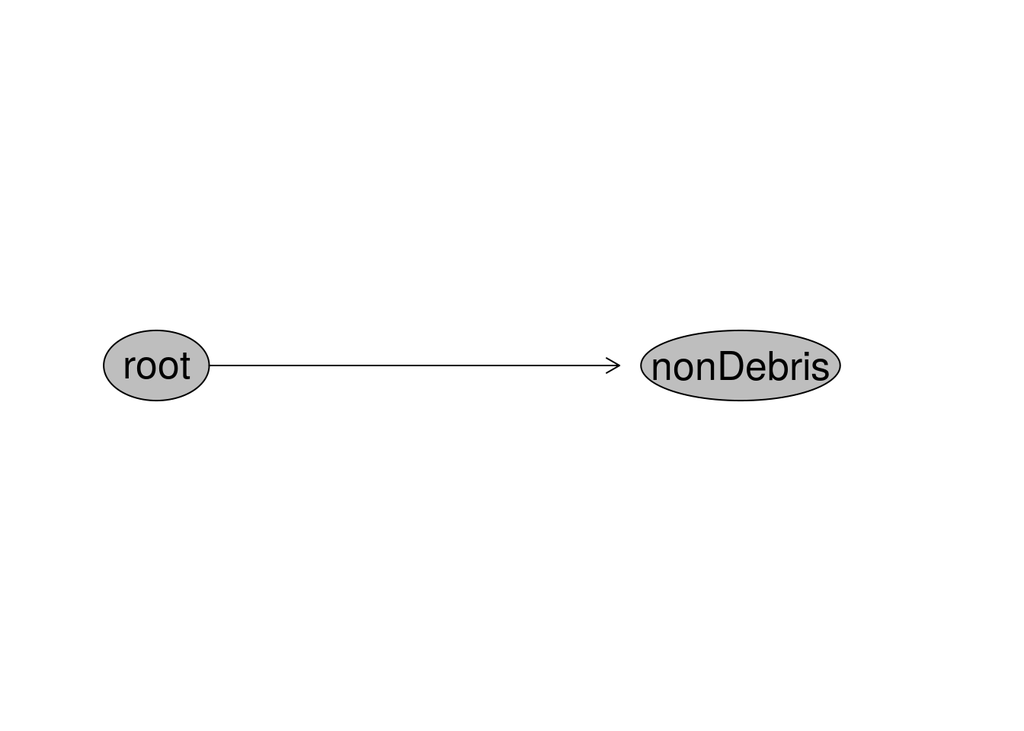

```r
plot(gs)
```

We can also pass the GatingStrategy into `autoplot` with the gate name:

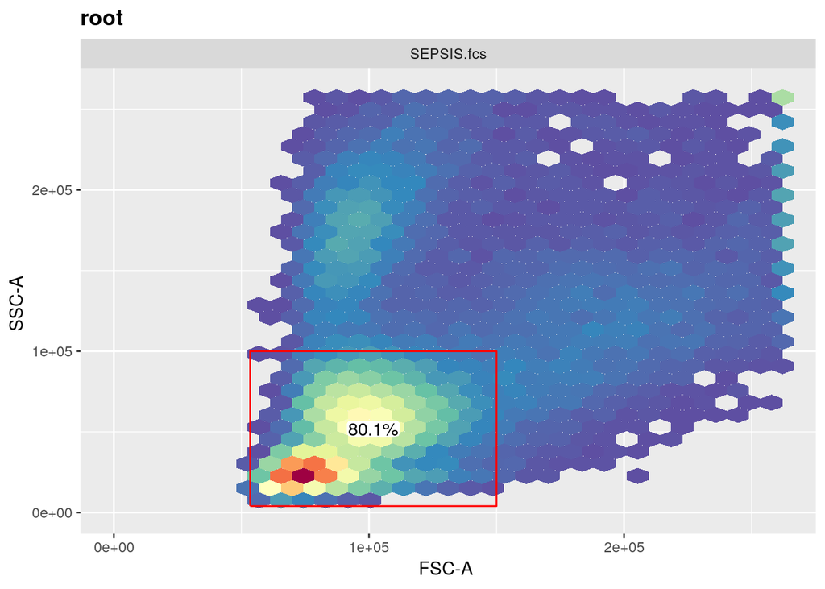

```r
autoplot(gs, "nonDebris")
```

There are also functions in place to extract statistics for a gated population:

```r
# Cell counts
getTotal(gs[[1]], "nonDebris")
```

```
## [1] 1006620
```

```r
# Proportion of parent
getProp(gs[[1]], "nonDebris")
```

```
## [1] 0.8007879
```

Lets push forward with our gating strategy. I’m going to use some simple data driven gates provided by openCyto. These functions take a flowFrame as their first argument.

flowClust uses density based clustering. It isn’t the cutting edge, there are better performing algorithms now. It returns a gate for a single population. It requires a bit of hand holding: by default it will choose the largest population, so sometimes you have to give it a target range, you also need to state the number of populations expected in the analysed 2d area, and you can also specify a quantile which will narrow the gate by ignoring everything greater than the chosen quantile.

```r
fr <- getData(gs, "nonDebris")[[1]]
tCell_gate <- openCyto::flowClust.2d(fr, "FSC-A","SSC-A", target=c(75000,25000), K=2, quantile = 0.9)
```

```
## The prior specification has no effect when usePrior=no
```

```
## Using the serial version of flowClust
```

```r
add(gs, tCell_gate, parent = "nonDebris", name = "T-Cells")
```

```
## replicating filter 'defaultEllipsoidGate' across samples!
```

```
## [1] 3
```

```r
recompute(gs)
```

```
## .
```

```
## done!
```

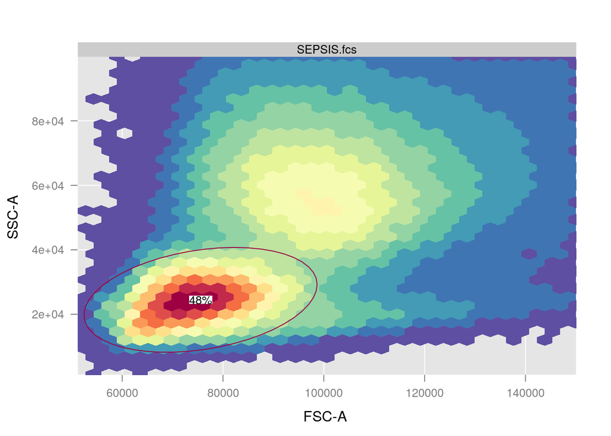

```r
plotGate(gs, "T-Cells", xlim = "data", ylim = "data")
```

Next, we’ll use a singlet gate:

```r
fr <- getData(gs, "T-Cells")[[1]]
singlet_gate <- openCyto:::.singletGate(fr, channels=c("FSC-A","FSC-H"), wider_gate=TRUE, prediction_level=0.99, maxit=15)
add(gs, singlet_gate, parent = "T-Cells", name = "SingleCells")
```

```
## replicating filter 'singlet' across samples!
```

```
## [1] 4
```

```r
recompute(gs)
```

```
## .
```

```
## done!
```

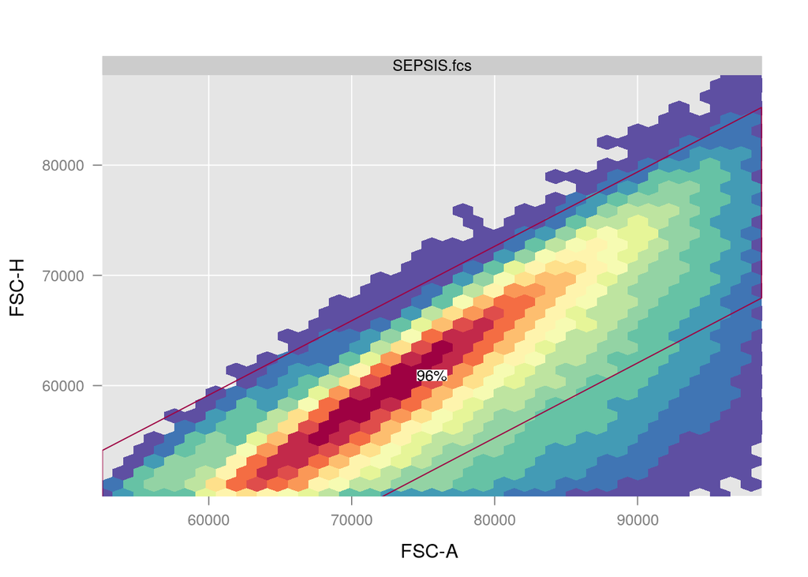

```r
plotGate(gs, "SingleCells", xlim = "data", ylim = "data")
```

```r
fr <- getData(gs, "SingleCells")[[1]]
liveCD3 <- openCyto::flowClust.2d(fr, "APC-Cy7-A","AmCyan-A", K=2, quantile = 0.9)
```

```
## The prior specification has no effect when usePrior=no
```

```
## Using the serial version of flowClust
```

```r
add(gs, liveCD3, parent = "SingleCells", name = "Live T-Cells")
```

```
## replicating filter 'defaultEllipsoidGate' across samples!
```

```
## [1] 5
```

```r
recompute(gs)
```

```
## .
```

```
## done!
```

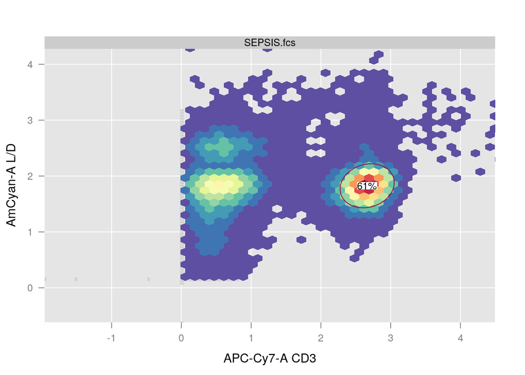

```r
#autoplot(fr, y="L/D", x="CD3", bins=128) + geom_gate(liveCD3)
plotGate(gs, "Live T-Cells", xlim = "data", ylim = "data")
```

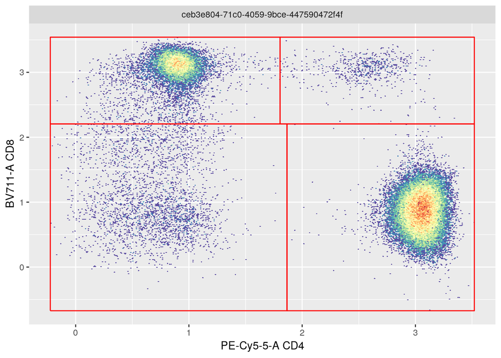

```r
fr <- getData(gs, "Live T-Cells")[[1]]
quadGate <- openCyto::gate_quad_sequential(fr, channels = c("BV711-A", "PE-Cy5-5-A"), gFunc='mindensity')
#add(gs, quadGate, parent = "Live T-Cells", name=c("CD8+", "NA", "CD4+", "NA"))
#recompute(gs)
autoplot(fr, "CD4", "CD8", bins=300) + geom_gate(quadGate)
```

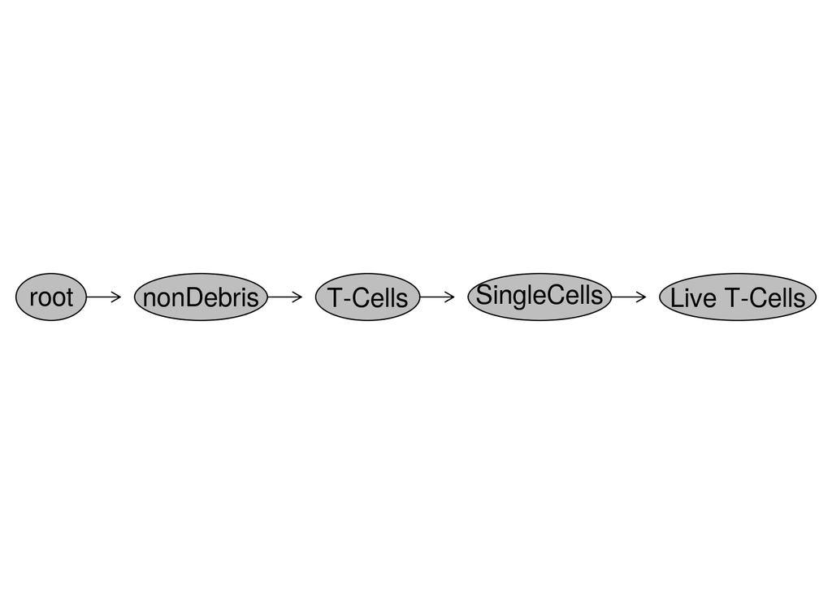

```r
plot(gs)
```

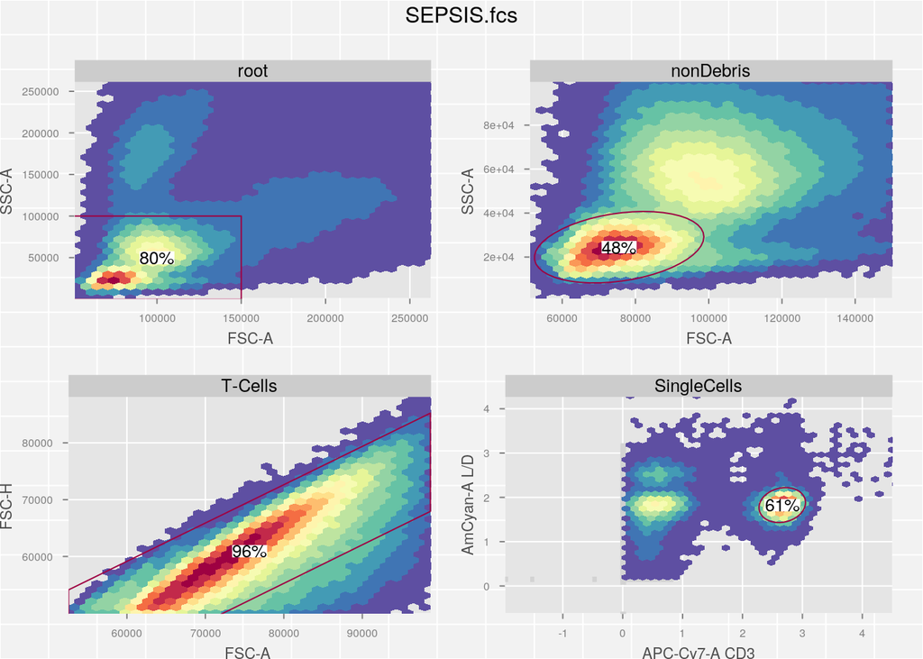

```r
plotGate(gs[[1]], xlim="data", ylim="data")
```

This is the manual way to setup a gating strategy for openCyto and is probably the best thing to do first, just so you can see that the gating is correct. But what you’re supposed to do next is setip a gating template.

Creating templaces is explained in the vignette:

- https://www.bioconductor.org/packages/release/bioc/vignettes/openCyto/inst/doc/openCytoVignette.html
- https://www.bioconductor.org/packages/release/bioc/vignettes/openCyto/inst/doc/HowToWriteCSVTemplate.html

## Gating Template

```r
template_file <- "/home/rossco/Documents/IIGeeks/flow/gating_template.csv"
template <- fread(template_file, autostart = 1L)
template
```

| alias | pop | parent | dims | gating_method | gating_args | collapseDataForGating | groupBy | preprocessing_method | preprocessing_args |
| --- | --- | --- | --- | --- | --- | --- | --- | --- | --- |
| nonDebris | + | root | FSC-A,SSC-A | boundary | min=c(50000,0),max=c(150000, 100000) | NA | NA | NA | NA |
| tCells | + | nonDebris | FSC-A,SSC-A | flowClust | target=c(75000,25000), K=2, quantile = 0.9 | NA | NA | NA | NA |
| singleCells | + | tCells | FSC-A,FSC-H | singletGate | wider_gate=TRUE, prediction_level=0.99, maxit=15 | NA | NA | NA | NA |
| liveCD3 | + | singleCells | APC-Cy7-A,AmCyan-A | flowClust | K=2, quantile = 0.9 | NA | NA | NA | NA |
| * | -/++/- | liveCD3 | BV711-A,PE-Cy5-5-A | mindensity |  | NA | NA | NA | NA |

```r
gt <- gatingTemplate(template_file)
```

```
## expanding pop: -/++/-
```

```
## Adding population:nonDebris
```

```
## Adding population:tCells
```

```
## Adding population:singleCells
```

```
## Adding population:liveCD3
```

```
## Adding population:BV711-A+
```

```
## Adding population:PE-Cy5-5-A+
```

```
## Adding population:BV711-A+PE-Cy5-5-A+
```

```
## Adding population:BV711-A-PE-Cy5-5-A+
```

```
## Adding population:BV711-A+PE-Cy5-5-A-
```

```
## Adding population:BV711-A-PE-Cy5-5-A-
```

```r
gt
```

```
## --- Gating Template: default
##  with  11  populations defined
```

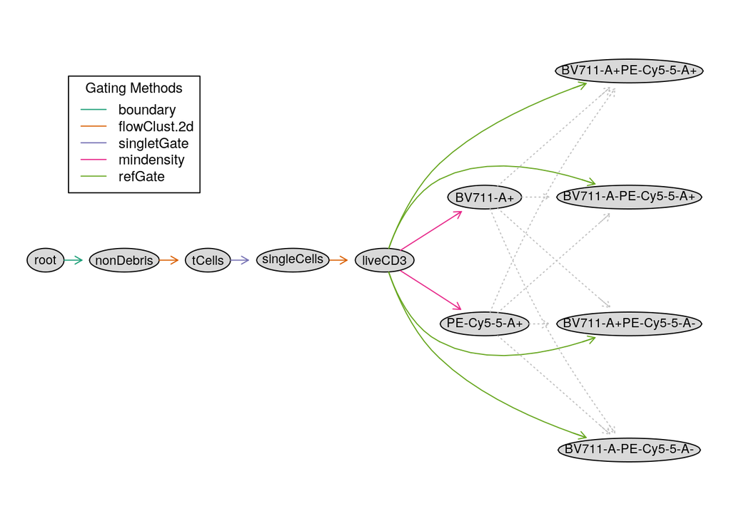

```r
plot(gt)
```

```r
Rm("nonDebris", gs)
```

```r
gating(gt, gs, mc.cores=2, parallel_type = "multicore")
```

```
## Gating for 'nonDebris'
```

```
## Running in parallel mode with 2 cores.
```

```
## done.
```

```
## Gating for 'tCells'
```

```
## Running in parallel mode with 2 cores.
```

```
## The prior specification has no effect when usePrior=no
```

```
## Using the serial version of flowClust
```

```
## done.
```

```
## Gating for 'singleCells'
```

```
## Running in parallel mode with 2 cores.
```

```
## done.
```

```
## Gating for 'liveCD3'
```

```
## Running in parallel mode with 2 cores.
```

```
## The prior specification has no effect when usePrior=no
```

```
## Using the serial version of flowClust
```

```
## done.
```

```
## Gating for 'PE-Cy5-5-A+'
```

```
## Running in parallel mode with 2 cores.
```

```
## done.
```

```
## Gating for 'BV711-A+'
```

```
## Running in parallel mode with 2 cores.
```

```
## done.
```

```
## Population 'BV711-A-PE-Cy5-5-A-'
```

```
## done.
```

```
## Population 'BV711-A+PE-Cy5-5-A-'
```

```
## done.
```

```
## Population 'BV711-A-PE-Cy5-5-A+'
```

```
## done.
```

```
## Population 'BV711-A+PE-Cy5-5-A+'
```

```
## done.
```

```
## finished.
```

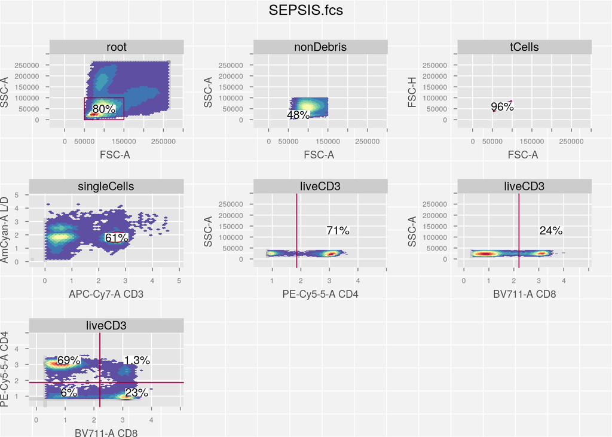

```r
plotGate(gs[[1]])
```

```r
cd4 <- exprs(getData(gs, "BV711-A-PE-Cy5-5-A+")[[1]])
cd8 <- exprs(getData(gs, "BV711-A+PE-Cy5-5-A-")[[1]])
```

```r
meaningfulNames <- function(fr, m){
  c_names <- colnames(fr)
  desc <- fr@parameters$desc
  for(i in seq(1,length(c_names))){
    if(!is.na(desc[i])){
      c_names[i] <- desc[i]
    }
  }
  colnames(m) <- paste(c_names)
  return(m)
}

cd4 <- meaningfulNames(getData(gs)[[1]], cd4)
cd8 <- meaningfulNames(getData(gs)[[1]], cd8)
```

```r
cd4 <- cbind(cd4, cell_type = c("CD4"))
cd8 <- cbind(cd8, cell_type = c("CD8"))
all <- rbind(cd4, cd8)[,c(7:20)][,-13]
```

```r
require(MASS)
write.matrix(all, file="dimensionality_reduction/SEPSIS.csv", sep=",")
```